# using_models_1

Briantama Asmara

10/26/2021

# Data preparation

```r
require(here)
here()
```

```
## [1] "D:/UMass/OneDrive - University of Massachusetts/Documents/env_data"
```

```r
catrate = data.frame(read.csv(here("data", "catrate.csv")))
head(catrate)
```

```
##   pond success years  cat.rate
## 1    2       5     7 0.2857143
## 2    3       5     7 0.2857143
## 3    4       6     7 0.1428571
## 4    5       4     7 0.4285714
## 5    6       0     7 1.0000000
## 6    7       1     4 0.7500000
```

```r
summary(catrate)
```

```
##       pond       success          years          cat.rate
##  Min.   : 2   Min.   :0.000   Min.   :1.000   Min.   :0.1429
##  1st Qu.: 5   1st Qu.:1.000   1st Qu.:3.000   1st Qu.:0.2857
##  Median : 8   Median :2.000   Median :4.000   Median :0.4286
##  Mean   : 8   Mean   :2.538   Mean   :4.692   Mean   :0.5394
##  3rd Qu.:11   3rd Qu.:5.000   3rd Qu.:7.000   3rd Qu.:0.7500
##  Max.   :14   Max.   :6.000   Max.   :7.000   Max.   :1.0000
```

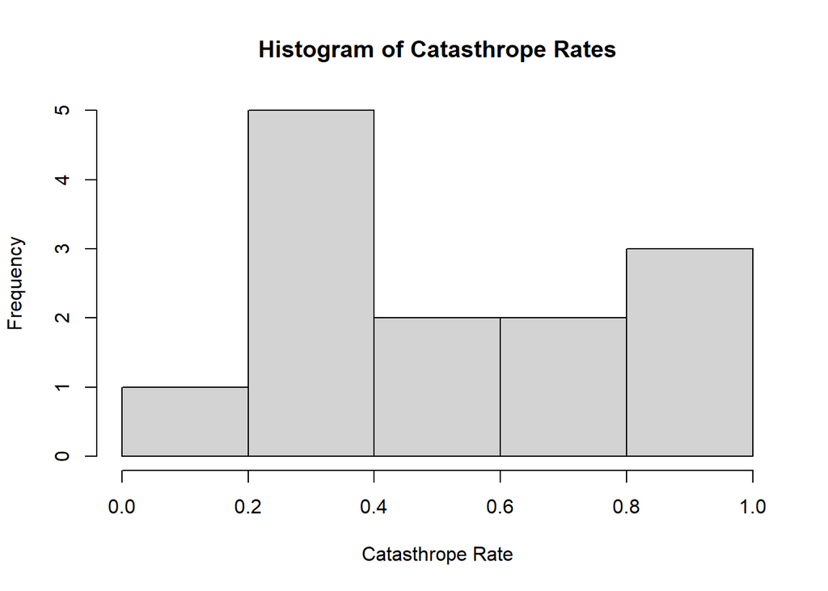

```r
hist(catrate$cat.rate,
     main = "Histogram of Catasthrope Rates",
     xlab = "Catasthrope Rate")
```

# Shapiro Test

```r
shapiro.test(catrate$cat.rate)
```

```
##
##  Shapiro-Wilk normality test
##
## data:  catrate$cat.rate
## W = 0.86202, p-value = 0.04097
```

# t-test

```r
t.test(catrate$cat.rate, mu = 0.3)
```

```
##
##  One Sample t-test
##
## data:  catrate$cat.rate
## t = 2.7928, df = 12, p-value = 0.01626
## alternative hypothesis: true mean is not equal to 0.3
## 95 percent confidence interval:
##  0.3526250 0.7261295
## sample estimates:
## mean of x
## 0.5393773
```

# One-sided Alternative Hypothesis

```r
t.test(catrate$cat.rate, mu = 0.3, alternative = "greater")
```

```
##
##  One Sample t-test
##
## data:  catrate$cat.rate
## t = 2.7928, df = 12, p-value = 0.00813
## alternative hypothesis: true mean is greater than 0.3
## 95 percent confidence interval:
##  0.3866123       Inf
## sample estimates:
## mean of x
## 0.5393773
```

```r
t.test(catrate$cat.rate, mu = 0.3, alternative = "less")
```

```
##
##  One Sample t-test
##
## data:  catrate$cat.rate
## t = 2.7928, df = 12, p-value = 0.9919
## alternative hypothesis: true mean is less than 0.3
## 95 percent confidence interval:
##       -Inf 0.6921422
## sample estimates:
## mean of x
## 0.5393773
```

# Wilcoxon Test

```r
wilcox.test(catrate$cat.rate, mu = 2/7, alternative = "greater")
```

```
##
##  Wilcoxon signed rank test with continuity correction
##
## data:  catrate$cat.rate
## V = 85, p-value = 0.003137
## alternative hypothesis: true location is greater than 0.2857143
```

# Two Sample Means Comparison

```r
require(palmerpenguins)
penguin_dat = droplevels(subset(penguins, species != "Gentoo"))
```

```r
summary(penguin_dat)
```

```
##       species          island    bill_length_mm  bill_depth_mm
##  Adelie   :152   Biscoe   : 44   Min.   :32.10   Min.   :15.50
##  Chinstrap: 68   Dream    :124   1st Qu.:37.75   1st Qu.:17.50
##                  Torgersen: 52   Median :40.60   Median :18.40
##                                  Mean   :41.91   Mean   :18.37
##                                  3rd Qu.:45.95   3rd Qu.:19.10
##                                  Max.   :58.00   Max.   :21.50
##                                  NA's   :1       NA's   :1
##  flipper_length_mm  body_mass_g       sex           year
##  Min.   :172.0     Min.   :2700   female:107   Min.   :2007
##  1st Qu.:187.0     1st Qu.:3400   male  :107   1st Qu.:2007
##  Median :191.0     Median :3700   NA's  :  6   Median :2008
##  Mean   :191.8     Mean   :3711                Mean   :2008
##  3rd Qu.:196.0     3rd Qu.:3988                3rd Qu.:2009
##  Max.   :212.0     Max.   :4800                Max.   :2009
##  NA's   :1         NA's   :1
```

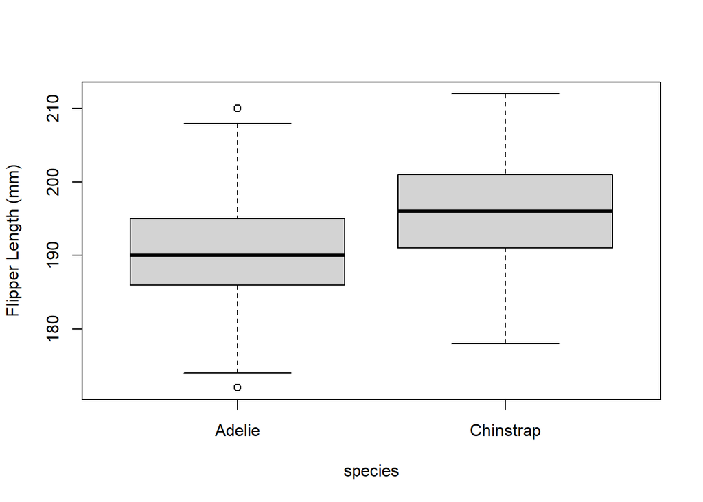

```r
boxplot(
  flipper_length_mm ~ species,
  data = penguin_dat,
  ylab = "Flipper Length (mm)")
```

# Testing for Normality

```r
dat_adelie = subset(penguin_dat,
                    species == "Adelie")
dat_chinstrap = subset(penguin_dat,
                       species == "Chinstrap")
```

# Parametric and Non-parametric

```r
head(dat_adelie)
```

```
##   species    island bill_length_mm bill_depth_mm flipper_length_mm body_mass_g
## 1  Adelie Torgersen           39.1          18.7               181        3750
## 2  Adelie Torgersen           39.5          17.4               186        3800
## 3  Adelie Torgersen           40.3          18.0               195        3250
## 4  Adelie Torgersen             NA            NA                NA          NA
## 5  Adelie Torgersen           36.7          19.3               193        3450
## 6  Adelie Torgersen           39.3          20.6               190        3650
##      sex year
## 1   male 2007
## 2 female 2007
## 3 female 2007
## 4   <NA> 2007
## 5 female 2007
## 6   male 2007
```

```r
shapiro.test(dat_adelie$bill_length_mm)
```

```
##
##  Shapiro-Wilk normality test
##
## data:  dat_adelie$bill_length_mm
## W = 0.99336, p-value = 0.7166
```

```r
shapiro.test(dat_chinstrap$bill_length_mm)
```

```
##
##  Shapiro-Wilk normality test
##
## data:  dat_chinstrap$bill_length_mm
## W = 0.97525, p-value = 0.1941
```

aggregate?

```r
t.test(flipper_length_mm ~ species,
       data = penguin_dat,
       )
```

```
##
##  Welch Two Sample t-test
##
## data:  flipper_length_mm by species
## t = -5.7804, df = 119.68, p-value = 6.049e-08
## alternative hypothesis: true difference in means between group Adelie and group Chinstrap is not equal to 0
## 95 percent confidence interval:
##  -7.880530 -3.859244
## sample estimates:
##    mean in group Adelie mean in group Chinstrap
##                189.9536                195.8235
```

```r
wilcox.test(flipper_length_mm ~ species,
       data = penguin_dat,
       )
```

```
##
##  Wilcoxon rank sum test with continuity correction
##
## data:  flipper_length_mm by species
## W = 2733.5, p-value = 3.028e-08
## alternative hypothesis: true location shift is not equal to 0
```

```r
levels(penguin_dat$species)
```

```
## [1] "Adelie"    "Chinstrap"
```

# Q1 Catasthropic Rate Histogram

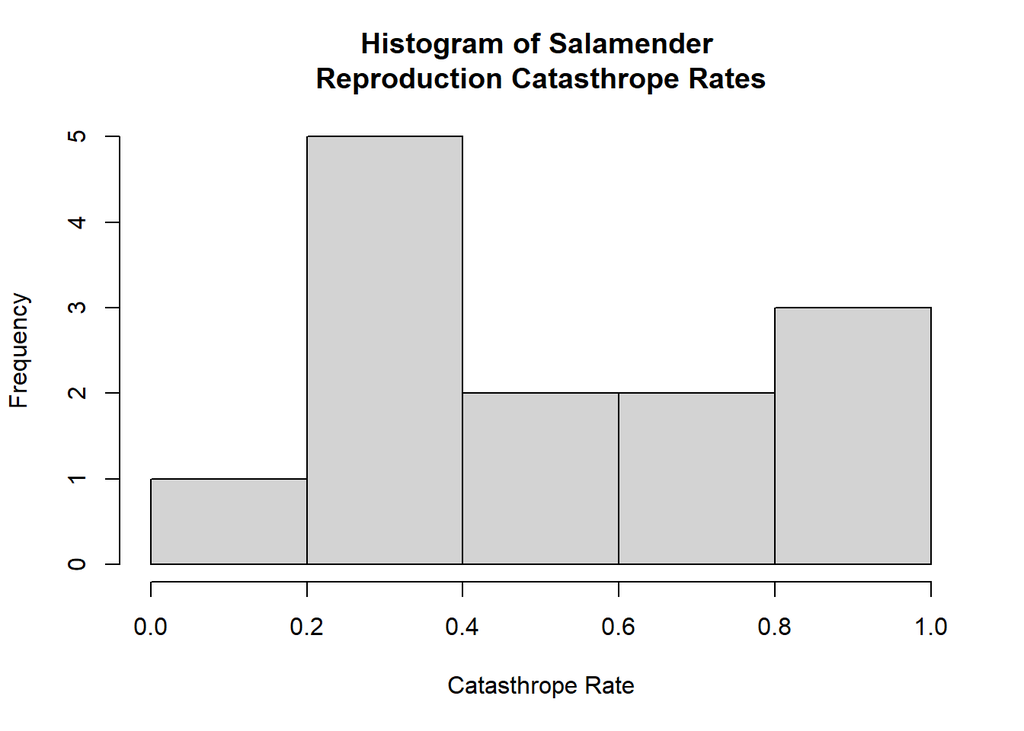

```r
hist(catrate$cat.rate,
     main = "Histogram of Salamender \nReproduction Catasthrope Rates",
     xlab = "Catasthrope Rate")
```

# Q2 Normality Test

```r
shapiro.test(catrate$cat.rate)
```

```
##
##  Shapiro-Wilk normality test
##
## data:  catrate$cat.rate
## W = 0.86202, p-value = 0.04097
```

The p-value is 0.04097

# Q3 Normality Test

The null-hypothesis is rejected due to low p-values. Thus, there is good evidence against the null-hypothesis; the sample does not come from normally distributed population.

# Q4 Normality Test

According to the p-value, it is lower (0.04) than the value of alpha (0.05). Therefore, it would suggest that there is a strong evidence that our sample is non-normally distributed. However, due to the slight differences (only 0.01), there is a probability that it could go either way (Type 1 error). I would prefer to state “good evidence” rather than "strong.

# Q5 t-test 1

Since we already know the data of both values, therefore I only use the two-tailed test

```r
t.test(catrate$cat.rate, mu = 2/7)
```

```
##
##  One Sample t-test
##
## data:  catrate$cat.rate
## t = 2.9595, df = 12, p-value = 0.01193
## alternative hypothesis: true mean is not equal to 0.2857143
## 95 percent confidence interval:
##  0.3526250 0.7261295
## sample estimates:
## mean of x
## 0.5393773
```

# Q6 t-test 1

At first, we want to know whether the catastrophe rate has the similar value with late-filling rate. However, what we have from the observation value of catastrophes rate is significantly different from what we expect from the late-filling rate; it can be lower or even greater, we don’t exactly know. This is based on there is not enough support to form a convincing conclusion on the similarities of the two samples

# Q7 t-test 1

This is two-tailed test because we only care whether two values are different from each other. It could go to two directions, it can be lower or even greater than the value we tested.

# Q8 t-test 2

The result of p-value from the t-test is 0.01193.

Since there is a strong evidence to deny the similarities between catastrophe rate and late-filling rate, we conclude that they are different from one another. However, there is still a small portion of probability (alpha = 1.1%) that, unfortunately, both samples have the same value. In that small chances of happening, they turned out to not even have any slightest differences. We picked the wrong conclusion. As we already rejected that, and it turns out to be a wrong decision, this is called “false positive”. We picked the wrong decision to reject the null hypothesis when it should be accepted as a null hypothesis because they have the same value.

# Q9 t-test 2

From our latest calculations, it shows the confidence interval of our t-test:

95 percent confidence interval: 0.3526250 0.7261295

This means the confidence interval spans from 0.35… to 0.7261…

It didn’t include zero, since the range of confidence interval only includes number from 0.35… to 0.7261…

# Q10 t-test 2

Yes, there is a strong evidence to reject null-hypothesis since our p-value shows 0.01193, which means lower than 0.05. Since there is only 1.2 percent of probability that suggests otherwise, it is relatively strong evidence to reach a conclusion to reject null hyothesis.

# Q11 Wilcoxon test 1

```r
wilcox.test(catrate$cat.rate, mu = 2 / 7)
```

```
##
##  Wilcoxon signed rank test with continuity correction
##
## data:  catrate$cat.rate
## V = 85, p-value = 0.006275
## alternative hypothesis: true location is not equal to 0.2857143
```

# Q12 Wilcoxon test 1

p-value from t-test: 0.0119

p-value from Wilcoxon test: 0.006275

The p-value from Wilcoxon test is slightly lower compared to the result of t-test. This is may related on their approach; t-test use parametric approach, while Wilcoxon incorporate nonparametric approach.

# Q13 Wilcoxon test 1

# Q14 Test Comparison

Overall, the results is different, but not by far. The value of Wilcoxon test has a stronger evidence to reject the null-hypothesis (0.006), rather than the p-value result from the t-test. However, it doesn’t entirely mean that it is better. The Wilcoxon test maybe better in this term due to lower sample size, but despite having a stronger evidence, I would prefer to choose t-test on a large sample.

# Q15 Test Comparison

```r
summary(catrate$cat.rate)
```

```
##    Min. 1st Qu.  Median    Mean 3rd Qu.    Max.
##  0.1429  0.2857  0.4286  0.5394  0.7500  1.0000
```

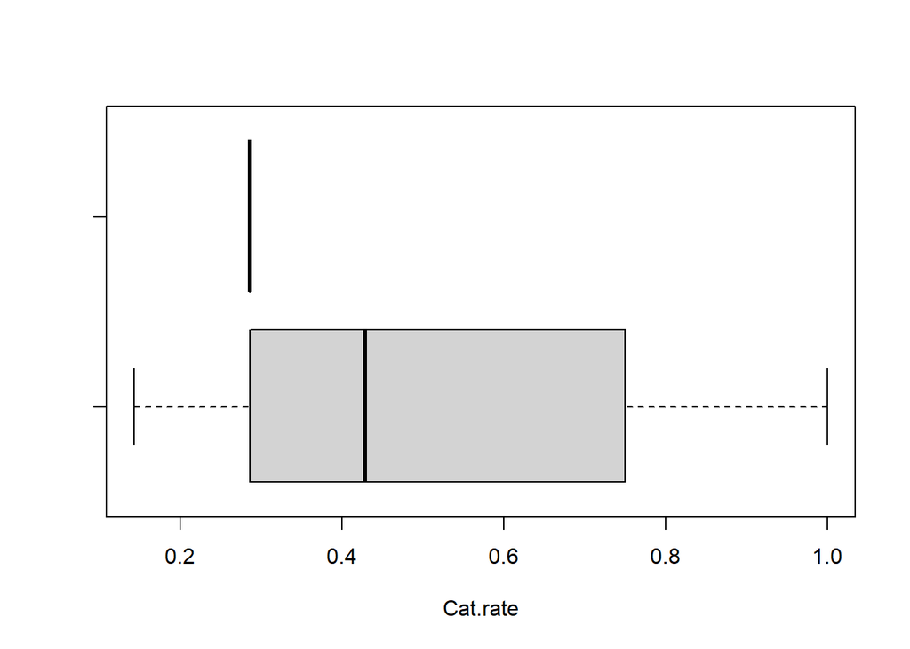

```r
boxplot(catrate$cat.rate, 2/7,
        horizontal = TRUE,
        xlab = "Cat.rate")
```

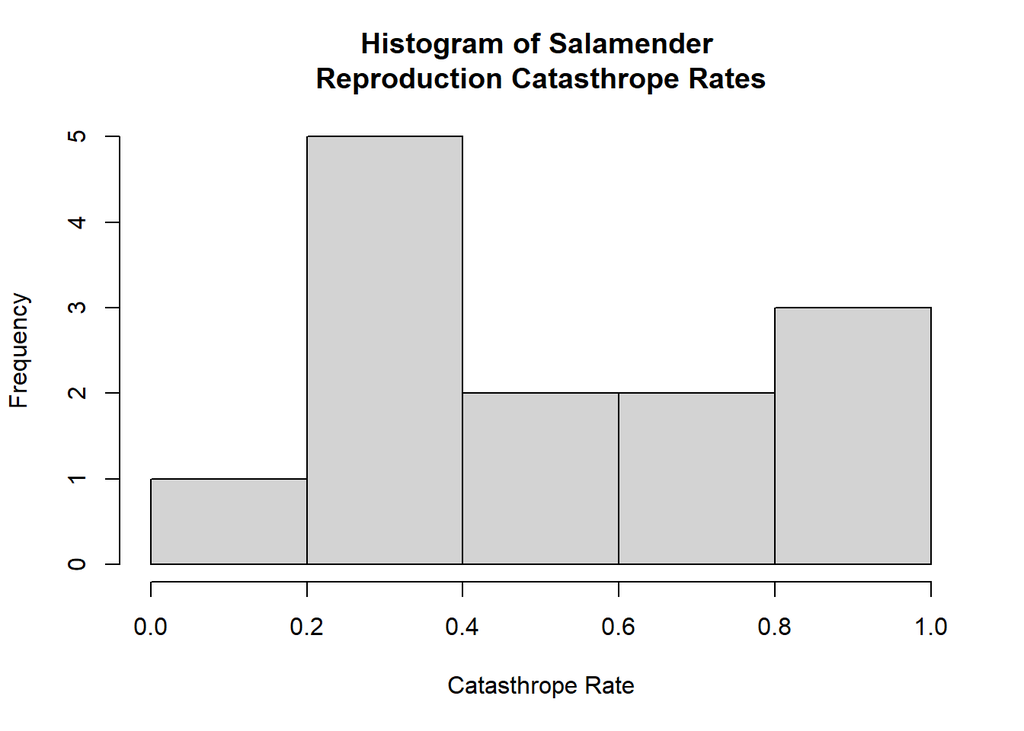

```r
hist(catrate$cat.rate,
     main = "Histogram of Salamender \nReproduction Catasthrope Rates",
     xlab = "Catasthrope Rate")
```

Based on the numerical and graphical data exploration, our sample frequency is pretty low (13 samples). Due to the consideration of low sample sizes of catastrophe data that we had been using so far, the results of Wilcoxon seems more appropriate and provide relatively accurate assessment. Despite some disadvantages of its weak statistical inferences in a general sense, the Wilcoxon test also show a stronger evidence to reject the null hypothesis.